# News

##### April 28, 2022

Version 1.1.0

- Added support for the following species:
  - Homo sapiens
  - Bos taurus
  - Caenorhabditis elegans
  - Canis familiaris
  - Danio rerio
  - Drosophila melanogaster
  - Gallus gallus
  - Mus musculus
  - Rattus norvegicus
  - Saccharomyces cerevisiae
  - Sus scrofa
  - Xenopus tropicalis
- Minor performance improvements

##### May 18, 2021

Version 1.0.4

- UI Fix
- Fixed links to socials
- Improved **Identifier tools -> Convert IDs**. Can now show single matches or all matches in case of one-to-many mapping between identifier types.
- Updated documentation (3.1 Identifier tools)

##### April 15, 2021

- Easier data import
- Improved PCA and heatmap functionality
- Tooltips everywhere
- Volcano plot for differential expression analysis
- Volcano plot for enrichment/network can switch between annotation modes

##### March 10, 2021

- Support for additional species: mouse and rat

##### November 04, 2020

- ProteoMill automatically detects and converts identifiers, but there is now a dedicated tool for converting arbitrary identifier lists between ID types.

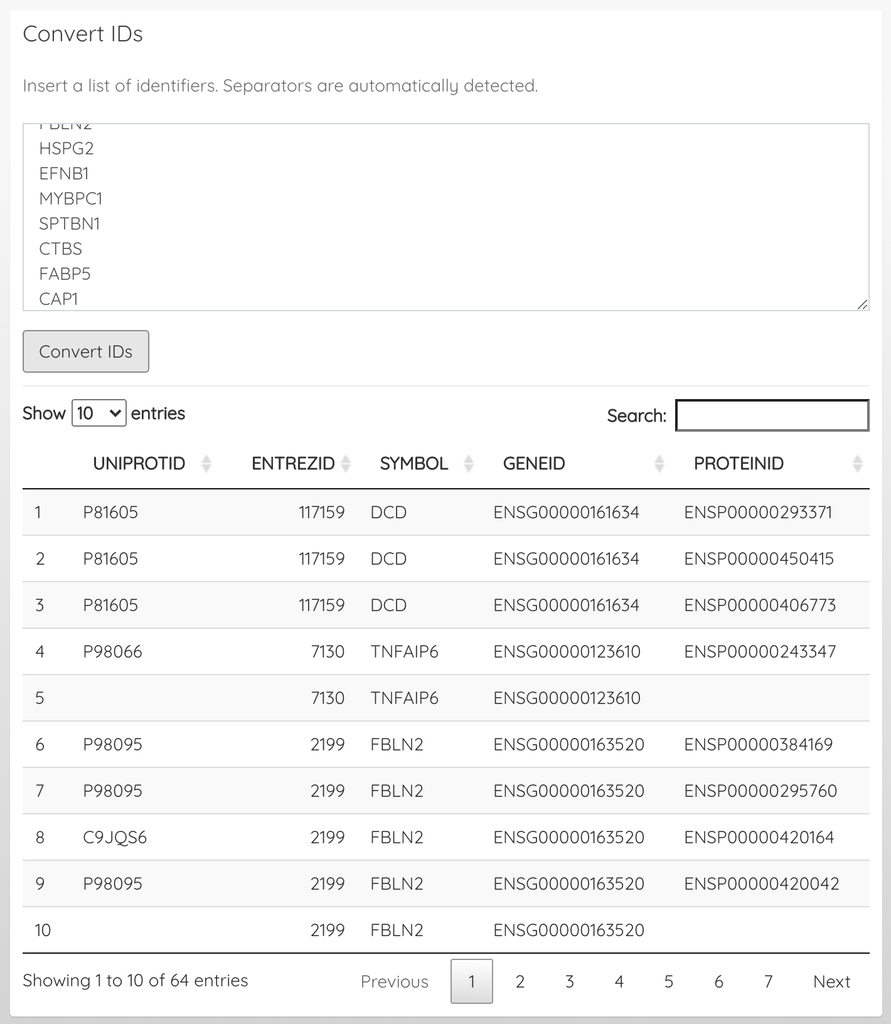

- Improved functionality for generating report

##### October 26, 2020

- 3D PCA plots now show sample names on hover

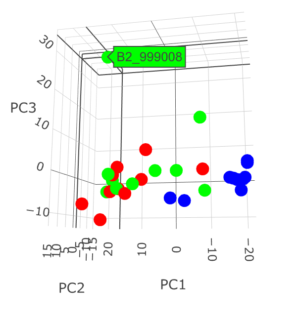

- Added splash-screen video
- Samples can be excluded (Dataset options > Data summary > Include/exclude samples)